# Reporte - Proyecto Final Métodos de Gran Escala

Equipo TienenDiez

3 de junio de 2015

## Introducción

La demanda de procesamiento de flujos en tiempo real está aumentando cada vez más. La razón es que a menudo el procesamiento de grandes volúmenes de datos no es suficiente. Los datos tiene que ser procesados rápidos para que una empresa pueda reaccionar a las condiciones cambiantes del negocio en tiempo real.

Web logs, RFID, sensor networks, social networks, social data, páginas de Internet, Indexado y búsqueda de páginas de internet, detalle de llamadas, datos astronómicos, ciencia, datos genómicos, biogeoquímicos, biológicos, vigilancia (cámas de vídeo, por ejemplo), biogeoquímicos, biológicos, registros médicos, fotografías, vídeo, transacciones bancarias, son ejemplos de lo que se puede procesar.

El siguiente es un esquema general de las herramientas que podemos utilizar. (Existen nuevas tendencias como Apache Kafka o combinacion de flume y kafka (Flafka) o el ecosistema que se esta formado en torno a spark)

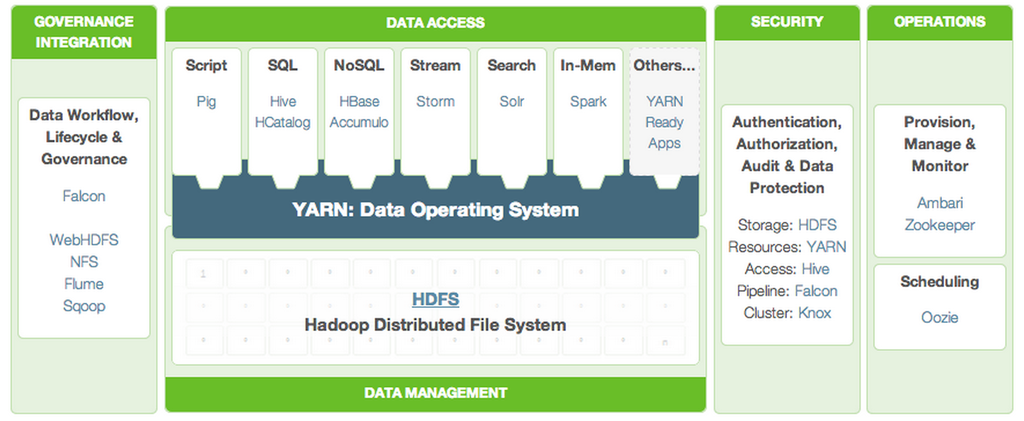

`Fuente: http://hortonworks.com/`

**Pero ¿Qué es Big data?**

Es un concepto relativo (como todo aquello que está relacionado con el tamaño) Cuando la información no viene en formatos estructurados Crecimiento acelerado en la adquisición de datos, hardware, alamacenamiento, paralelismo, tiempo de proceso, etc. Análisis de datos de varias fuentes distintas

## Objetivo

En el siguiente trabajo utilizamos herramientas para procesamiento de flujo de datos.

- Recolección de documentos GDELT de la página con Flume
- Importación de documentos de carpetas hacia HDFS - AVRO
- Uso Hive, Pig y Spark para procesar los datos
- Importar los datos procesados a R
- Visualización

## Datos GDELT

GDELT es un proyecto que contiene más de 300 millones de eventos geolocalizados desde 1979 a la fecha. Los datos se basan en informes de noticias de una variedad de fuentes internacionales codificadas usando el sistema de TABARI para registrar los eventos y el uso de software adicional para la ubicación y el tono. Los datos son de libre disposición y actualizadas diariamente.

## Uso potencial de los datos GDELT

La base de GDELT nos puede ofrecer registros de eventos de conflictos a lo largo de toda la república mexicana y del mundo. Como por ejemplo podemos distinguir en el siguiente gráfico las zonas con mayores conflictos registrados.

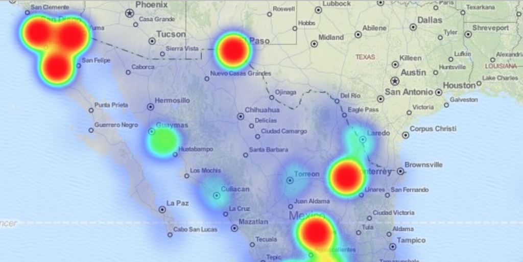

## Data Flow

**GDELT**

- Obtención
  - Diariamente, scrappear la página de GDELT para ver si han subido algo nuevo.
  - Cuando suban algo nuevo, bajar las bases nuevas (HTML).
- Limpieza
  - Generar el CSV a partir del HTML.
  - Limpiar y validar el CSV (bash).
- Carga
  - Hadoop
    - Usar un spoolDir de Flume para subirlo
    - Subir al HDFS y agregarlo al dataset en formato Avro.
- Orquestación
  - Luigi
    - Analítica
      - Hive
      - Pig
    - Manipulación
      - Exportamos resultados
- Visualización
  - Shiny (series de tiempo) o Markdown.

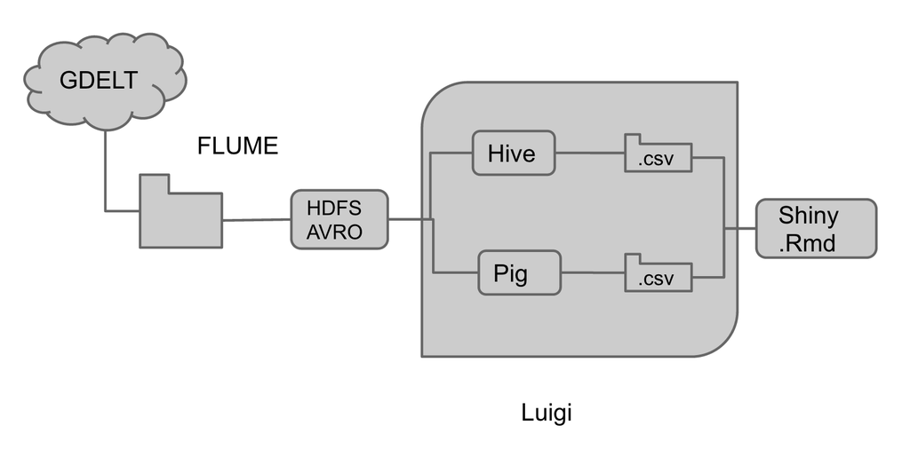

## Ejecución

```r
# Crear la instancia
docker run -ti --name hadoop-pseudo-proyecto \
       -v /Users/Felipe/data-science/final-big-data:/home/itam/localhost \
       -p 2122:2122 -p 2181:2181 -p 39534:39534 -p 9000:9000 \
       -p 50070:50070 -p 50010:50010 -p 50020:50020 -p 50075:50075 \
       -p 50090:50090 -p 8030:8030 -p 8031:8031 -p 8032:8032 \
       -p 8033:8033 -p 8088:8088 -p 8040:8040 -p 8042:8042 \
       -p 13562:13562 -p 47784:47784 -p 10020:10020 -p 19888:19888 \
       -p 8000:8000 -p 9999:9999 \
       --net=host \
       nanounanue/docker-hadoop


# Cambiar al usuario itam
su itam

# Para tener el comando man
sudo apt-get install man-db

# Necesario para usar Flume
sudo ln -s /usr/lib/kite/kite-morphlines-* /usr/lib/flume-ng/lib
sudo ln -s /usr/lib/kite/lib/metrics* /usr/lib/flume-ng/lib
sudo ln -s /usr/lib/kite/lib/config-1.0.2.jar /usr/lib/flume-ng/lib
sudo ln -s /usr/lib/kite/lib/Saxon-HE-9.5.1-5.jar /usr/lib/flume-ng/lib
sudo ln -s /usr/lib/kite/lib/tika-* /usr/lib/flume-ng/lib

# Correr el contenedor si ya se había creado
docker start -ia hadoop-pseudo-proyecto

#---------------------------------------------------------------------------------------------------------------
# Creamos las carpetas
sudo -u hdfs hadoop fs -mkdir /user/itam
sudo -u hdfs hadoop fs -chown itam:itam /user/itam

#---------------------------------------------------------------------------------------------------------------
# Generar el esquema de los datos

curl http://gdeltproject.org/data/lookups/CSV.header.dailyupdates.txt > data/gdelt_headers.tsv
unzip -p data/raw/20130412.export.CSV.zip | cat data/gdelt_headers.tsv - > data/schema/20130412.export.CSV
kite-dataset csv-schema data/schema/20130412.export.CSV --class GDELT --delimiter "\t" -o data/schema/gdelt_raw20130412.avsc


# Crear el dataset en el hive metastore.

kite-dataset create dataset:hive:gdelt --schema data/schema/gdelt.avsc

# El dataset queda en: /user/hive/warehouse/gdelt
hadoop fs -ls -R /user/hive

#---------------------------------------------------------------------------------------------------------------

# Probamos importar unos datos
#unzip -p data/raw/20130412.export.CSV.zip | cat data/gdelt_headers.tsv - > data/spool/20130412.export.CSV
#kite-dataset csv-import data/spool/20130412.export.CSV dataset:hive:gdelt --delimiter "\t"
#hadoop fs -ls -R /user/hive

# Podemos ver los datos en HIVE
#beeline -u jdbc:hive2://localhost:10000
#show tables;
#select * from gdelt limit 10;

# Borramos el dataset de pruebas (hay que crearlo de nuevo)
#kite-dataset delete dataset:hive:gdelt

### END NOT RUN ###

#---------------------------------------------------------------------------------------------------------------

# Corremos el agente de flume
# NOTA: Preferímos usar un sink en Avro directo al HDFS.

flume-ng agent -n GDELTAgent -Xmx300m --conf flume -f flume/gdelt-agent.conf

# Abrir otra conexión al contenedor
docker exec -it hadoop-pseudo-proyecto /bin/zsh
su itam

# Correr el código que baja los datos y los mete al spoolDir
./process_background.sh data/raw data/spool 5
```

#### Flume agent (gdelt-agent.conf)

```r
# Componentes
GDELTAgent.sources = GDELTDir
GDELTAgent.channels = archivo
GDELTAgent.sinks = GDELTKiteDS

# Canal
#GDELTAgent.channels.archivo.type = file
#GDELTAgent.channels.archivo.checkpointDir = /home/itam/localhost/playground/data/spool/log/checkpoint/
#GDELTAgent.channels.archivo.dataDirs = /home/itam/localhost/playground/data/spool/log/data/
#GDELTAgent.channels.archivo.checkpointInterval = 5000
#GDELTAgent.channels.archivo.capacity = 20
#GDELTAgent.channels.archivo.transactionCapacity = 10

GDELTAgent.channels.archivo.type = memory
GDELTAgent.channels.archivo.capacity = 10000000
GDELTAgent.channels.archivo.transactionCapacity = 1000000
#GDELTAgent.channels.archivo.byteCapacity = 1000000

# Fuente
GDELTAgent.sources.GDELTDir.type = spooldir
GDELTAgent.sources.GDELTDir.channels = archivo
GDELTAgent.sources.GDELTDir.spoolDir = /home/itam/localhost/playground/data/spool
GDELTAgent.sources.GDELTDir.fileHeader = true
GDELTAgent.sources.GDELTDir.deletePolicy = immediate

# Interceptor
GDELTAgent.sources.GDELTDir.interceptors = attach-schema morphline

GDELTAgent.sources.GDELTDir.interceptors.attach-schema.type = static
GDELTAgent.sources.GDELTDir.interceptors.attach-schema.key = flume.avro.schema.url
GDELTAgent.sources.GDELTDir.interceptors.attach-schema.value = file:/home/itam/localhost/playground/data/schema/gdelt.avsc

GDELTAgent.sources.GDELTDir.interceptors.morphline.type = org.apache.flume.sink.solr.morphline.MorphlineInterceptor$Builder
GDELTAgent.sources.GDELTDir.interceptors.morphline.morphlineFile = /home/itam/localhost/playground/flume/morphline.conf
GDELTAgent.sources.GDELTDir.interceptors.morphline.morphlineId = convertGDELTFileToAvro


# Sumidero
GDELTAgent.sinks.GDELTKiteDS.type = hdfs
GDELTAgent.sinks.GDELTKiteDS.channel = archivo
GDELTAgent.sinks.GDELTKiteDS.hdfs.path = /user/hive/warehouse/gdelt
GDELTAgent.sinks.GDELTKiteDS.hdfs.fileType = DataStream
GDELTAgent.sinks.GDELTKiteDS.hdfs.rollInterval = 5
GDELTAgent.sinks.GDELTKiteDS.hdfs.batchSize = 100000
GDELTAgent.sinks.GDELTKiteDS.hdfs.filePrefix = GDELTData
GDELTAgent.sinks.GDELTKiteDS.hdfs.fileSuffix = .avro
GDELTAgent.sinks.GDELTKiteDS.hdfs.writeFormat = Avro
GDELTAgent.sinks.GDELTKiteDS.hdfs.rollSize = 0
GDELTAgent.sinks.GDELTKiteDS.hdfs.rollCount = 1000000
GDELTAgent.sinks.GDELTKiteDS.serializer = org.apache.flume.sink.hdfs.AvroEventSerializer$Builder
#GDELTAgent.sinks.GDELTKiteDS.type = org.apache.flume.sink.kite.DatasetSink
#GDELTAgent.sinks.GDELTKiteDS.channel = archivo
#GDELTAgent.sinks.GDELTKiteDS.kite.dataset.uri = dataset:hive://0.0.0.0:9083/gdelt
#GDELTAgent.sinks.GDELTKiteDS.kite.dataset.name = gdelt
#GDELTAgent.sinks.GDELTKiteDS.kite.batchSize = 100
#GDELTAgent.sinks.GDELTKiteDS.kite.rollInterval = 5
```

#### Orquestación LUIGI (luigi-workflow.py)

```python
import random as rnd
import time
import os
import luigi


class MainTask(luigi.Task):
    def complete(self):
    return False

    def output(self):
        return luigi.LocalTarget('tmp/main_task_.txt')

    def requires(self):
    child_tasks = {"hive_query_1":1,"hive_query_2":2,"hive_query_3":3}
    tasks = []
        for item in child_tasks:
                print "Starting with task at:",item
                tasks.append(Export(child_tasks[item]))
        return tasks

    def run(self):

        # esto de aqui abajo es por el comentario (***)
        with self.output().open('w') as f:
            f.write("main task done...")



class Export(luigi.Task):
    rseed = luigi.IntParameter(default=1)

    def complete(self):
        return False

    def output(self):
        """ (***)
    luigi.Task.output es una funcion que escribe en un archivo local como
    acknowledgement que la tarea termino. Si este archivo existe, la tarea
    ya no se ejecuta.
    """
    return luigi.LocalTarget('/tmp/log_hive_task_%s.txt' % self.rseed)


    def requires(self): # esta tarea no tiene dependencias en otras
    return None

    def run(self):
    if self.rseed == 1:
        query = "hive -e 'set hive.cli.print.header=true; SELECT MonthYear, ActionGeo_Long, ActionGeo_Lat, ActionGeo_FullName FROM gdelt limit 1000' | sed 's/[\t]/,/g' > data/map_hive_%d.csv"%self.rseed
    elif self.rseed == 2: # second query
        query = """hive -e "SELECT MonthYear, ActionGeo_Long, ActionGeo_Lat, ActionGeo_FullName,count(*) c_mx FROM gdelt WHERE EventRootCode = '19' AND ActionGeo_CountryCode = 'MX' GROUP BY MonthYear, ActionGeo_Long, ActionGeo_Lat, ActionGeo_FullName ORDER BY MonthYear" | sed 's/[\t]/,/g'  > /data/conflictos.csv"""
    elif self.rseed == 3:
        query = """hive -e "SELECT Year, Actor1Name, Actor2Name, Count FROM (SELECT Actor1Name, Actor2Name, Year, COUNT(*) Count, RANK() OVER(PARTITION BY YEAR ORDER BY Count DESC) rank FROM SELECT Actor1Name, Actor2Name,  Year FROM gdelt WHERE Actor1Name < Actor2Name and Actor1CountryCode != '' and Actor2CountryCode != '' and Actor1CountryCode!=Actor2CountryCode and ActionGeo_CountryCode='MX'), ( SELECT Actor2Name Actor1Name, Actor1Name Actor2Name, Year FROM gdelt WHERE Actor1Name > Actor2Name  and Actor1CountryCode != '' and Actor2CountryCode != '' and Actor1CountryCode!= Actor2CountryCode and ActionGeo_CountryCode='MX'), WHERE Actor1Name IS NOT null AND Actor2Name IS NOT null GROUP EACH BY 1, 2, 3 HAVING Count > 100 ) WHERE rank=1 ORDER BY Year" | sed 's/[\t]/,/g'  > /data/actores.csv"""
    output = os.popen(query)

    # esto de aqui abajo es por el comentario (***)
        with self.output().open('w') as f:
            f.write(output.read())


if __name__ == '__main__':
    luigi.run(main_task_cls=MainTask)
```

## Resultados (visualizaciones)

**Registro de conflictos en México**

[figure not shown]

**Eventos en México en el tiempo (eventos en mexico entre total de ese periodo)**

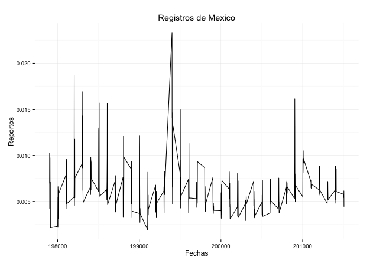

**Eventos que se relacionan con el Actor Mexico**

| Year | Actor1Name | Actor2Name | Count |
| --- | --- | --- | --- |
| 1980 | MEXICO | UNITED STATES | 118 |
| 1981 | MEXICO | UNITED STATES | 179 |
| 1982 | MEXICO | UNITED STATES | 225 |
| 1983 | MEXICO | UNITED STATES | 326 |
| 1984 | MEXICO | UNITED STATES | 291 |
| 1985 | MEXICO | UNITED STATES | 433 |
| 1986 | MEXICO | UNITED STATES | 334 |
| 1987 | MEXICO | UNITED STATES | 224 |
| 1988 | MEXICO | UNITED STATES | 267 |
| 1989 | MEXICO | UNITED STATES | 213 |

## ANEXOS

**Analítica PIG**

```r
PIG

## creamos hdfs.

kite-dataset create dataset:hdfs:/user/itam/datasets/gdelt --schema data/gdelt.avsc

kite-dataset csv-import data/20130412.export.CSV dataset:hdfs:/user/itam/datasets/gdelt --delimiter "\t"

## entramos grunt

pig -useHCatalog

### CARGAMOS avro

gdelt = LOAD 'datasets/gdelt' USING org.apache.pig.piggybank.storage.avro.AvroStorage();

### visualizando la tabla de gdelt

head = LIMIT gdelt 5;
DUMP head;

#guardamos TEORICO. NO se ha probado.
store head into '/user/itam/data/head' using PigStorage('\t','-schema');


##########################################################
### visualizamos Actores distintos.

Actor1Name = DISTINCT (FOREACH gdelt GENERATE Actor1Name);
DUMP Actor1Name;


### Visualizamos los países

gdelt2 = FILTER gdelt by ActionGeo_CountryCode != '';
country = DISTINCT (FOREACH gdelt2 GENERATE ActionGeo_CountryCode);
DUMP country;


### Contamos los eventos por actor principal pais.

gdelt_grp = GROUP gdelt by Actor1CountryCode;
country = FOREACH gdelt GENERATE Actor1CountryCode;
gdelt_cnt = FOREACH gdelt_grp GENERATE GROUP AS country, COUNT(gdelt) as count;
DUMP gdelt_cnt;


### Contar el total de lineas
### SELECT COUNT(*) FROM gdelt;

gdelt_grp = GROUP gdelt all;
gdelt_cnt = FOREACH gdelt_grp GENERATE COUNT(gdelt);
DUMP gdelt_cnt;

### Contar los distitntos EventCode  (clasificacion del evento)
### SELECT COUNT(DISTINCT EventCode) FROM gdelt;

event = DISTINCT(FOREACH gdelt GENERATE EventCode);
event_grp = GROUP event all;
event_cnt = FOREACH event_grp GENERATE COUNT(event);
DUMP event_cnt;
```

**Analítica pyspark**

```r
### pyspark


import csv
from io import StringIO

def load_tsv(archivo):
    return csv.reader(StringIO(archivo[1]), delimiter='\t')


####  Actor1Code

gdelt = sc.textFile("hdfs://localhost/user/itam/data/20130412.export.CSV").flatMap(load_tsv)
gdelt.take(3)[5]

#### Contamos el numero diferente de eventos
#### gdelt = sc.textFile("hdfs://localhost/user/itam/data/20130412.export.CSV")

gdelt.map(lambda line: (line.split('\t')[22]))\
.distinct()\
.count()

### contamos registro
gdelt.count()
```